# Do Homebuyers Care About Good Grades?: Evaluating the Effect of NYC School Accountability Program on Housing Values

John Ihor Campagna

December 3, 2017

## I. Introduction/Motivation

-2006-2007 First year of New York City Progress Reports under Bloomberg

-Followed No Child Left Behind(NCLB) in 2001 under President Bush and State level in Florida and Texas in 90s

-Broadly intial Goals were to pressure schools to reform and improve student outcomes

-The nature of how the grades were implemented provided a unique discontinuity that had many applications

-The housing market is one application seeing how parents respond to an imperfect measure of school quality and what broader consequneces could be.

-NYC accountabilty program provides a large urban, and multiple ethnic context to explore the consequences

## I Background: School Accountability Literature

1. School Accountability Literature

Student Outcomes

-Rockoff(2010)

-Cowen and Winters(2011)

-Elena Rouse et al(2013)

Labor Market -Dizon-Ross (2017)

Demographic -Hart and Figlio (2015)

Long Term -Deming et al. (2016)

## I. Background: School Quality Literature

2.school Quality Literature

-Black(1999)

Sorting/Demographic

-Bayer et al(2007)

-Clapp(2008)

Value Added

-Brassington and Haurin(2006)

-Chiodo et al (2010)

-Horn(2014) NYC choice schools

## II Background: School Quality and Accountability

3. School Quality and Accountability

-Figlio and Lucas(2004)

-Ideal to get starting effects of accountability as effect appears to decrease over time

-Kane et al (2002) no effect NC, race matters black scores not as important

-Martinez (2010) effect NC

## III. Data

Drawn from Multiple Sources

1. NYC DOE
- Accountability Scores
- Test Score Data
- School Demographic
- School Zones
2. Property Data

-Property Transactions

-Property Location data

3. Cenus Data

-Likely need for neighborhood controls

## III. Summary Stats

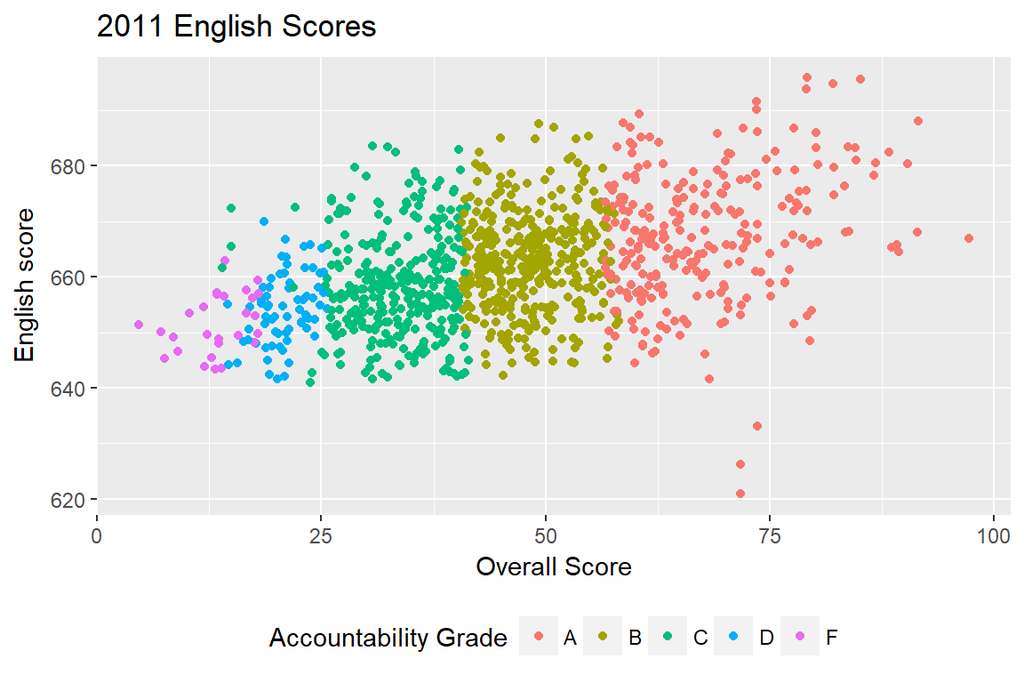

[figure not shown]

## IV. Model: Hedonic

1. Classic Hedonic -Rosen(1974) -Revealed preference model of estimation

$$\ ln(P_{i,z,n}) = \alpha+X_{i,n}+Z_{n}+\Gamma_{z}+e_{i,z,t}$$

-$X_{i,z}$ is a vector of Housing characteristics -$Z_{z,n}$ is school zone characteristics -$\gamma$ is the school quality measure -$\e_{i,z,t}$ error term

# IV. Model: BDD

2. BDD

-Black(1999)

-$Z_{z,n}$ from the hedonic model may not account for everything

-Assumes properties that are arbitrarily close to a school zone boundary have the same characristics

$$(2) \ ln(P_{i,z,b}) = \alpha+X_{i,z,b}+K_{b}+\Gamma_{z}+e_{i,z,t}$$
-$Z_{z,n}$ goes away replaced by $K_{b}$ which is a vector of boundary dummies -Still may be issue as Bayer(2007) show so may still need neighborhood controls

# IV. Model: Fixed Effects

3. Fixed Effects

-All Accountability School Quality Papers have employed this strategey -Figlio(2002)…does this need to control for schools? Because of fixed effects neighborhood and invidiual prop characteristics don’t need to be controlled? Add test scores as well? Only Compare A/B, B/C, C/D, D/F

$$(3) \ ln(P_{i,n,z,m,y}) = \alpha_{i} +X_{i,z,y}+Z_{i,y}+\beta_{m} +\Gamma_{i,z,t}+e_{i,n,z,m,y}$$

-$\ln(P_{i,n,z,m,y})$ is the price for for property i, in school zone z, month m, year y

-$\alpha_{i}$ captures fixed property effects that don’t change over time

-$\beta_m{m}$ are monthly dummies

Other Models -Look at same schools where the grade has changed in a year -Bandwiths in regards to RDD could also be used. EG really look at schools that were arbitarily close that could have recieved either A/B so compare 88-92. Can treat like regular RDD

## V. Problems/To Do

Problems

-Missing Earlier Data

-Problem of grade churning and changing over time

-Middle Schools

-Census Tract Data

-Distance -Perpahs can just capture schools that are arbitrarily close to a school assuming that they are in the same school zone and at least look at what the effect year on year is e.g. What happened for schools assigned an F v those assigned a D -Boundaries that are not natural or random i.e. a highway or river dividing a school zone